# Grapevine xf Analysis 5

Daniel Turek

### Updates in Analysis 5

- Added probabilistic transmission models for bacteria at source plant test sites, and for transmission of bacteria to vectors. There is enough information in the data to support different probabilities for each genotype.
- Updated Hierarchical Model (mathematical) description, to describe new probabilistic transmission models.
- Increased number of MCMC iterations from 50,000 to 110,000 to support additional parameters (with burnin of 10,000). MCMC runtime is still very manageable.
- These changes in the model gave rise to many new and interesting “significant” results. It’s worth looking carefully again at all the results sections.
- Updated Interpretations section, to reflect new posterior results of all model parameters.
- New Posterior Density Plots added, to compare source plant transmission probabilities (DSF vs. WT), and vector transmission probabilities (DSF vs. WT).
- Updated Hierarchical Plots, now shows a more accurate depiction of probability of infection as a function of vector xf concentration. I believe this will better agree with the results from the GLMM.

### Updates in Analysis 4

- New hierarchical plots added

### Updates in Analysis 3

- Using new `dsf_data_for_nimble.rds` data file:
  - Corrected (switched) designations of DSF and WT genotypes
  - Data uses method for estimating the xf concentration in vectors from the qPCR test
- Interpretations section has beed carefully updated and revised, since most of the results regarding DSF and WT genotypes have switched. In addition, a number of the other numerical results have changed.
- New predictions included for probability of infection. In addition to predicting (for each genotype) at distance = 0, we also collect samples of probability of infection for *all* plants, which is representative of *all* distances. Summary statistics and posterior density plots for both types of predictions are included, which have explanable differences, but show nice agreement.

### Updates in Analysis 2

- Vector xf concentration $(\lambda^i_{vector})$ a modelled as a linear function of the source plant xf concentration $(\lambda^i_{plant})$. Further, this linear relationship includes an interaction with genotype, so we separately model this linear relationship for each source plant genotype.
- Tried introducing a probabilistic model for whether the vectors acquire *any* xf bacteria from the source plant, as a function of plant genotype, to account for the “patchiness” of the bacteria in DSF plants. However, this introduced a lack of identfyability between the probability of *transmitting* bacteria to the vectors (not currently in the model) and the probability of *observing* bacteria in the vectors (in the model). So this probabilistic model for transmission from source plants to vectors was removed.
- The model for test plant infection was augmented to include a dependence on plant genotype.
- Simplified the parameterizations of interaction terms, for better interpretability. The mathematical description of the hierarchical model more clearly presents the biological processes for genotype DSF and WT plants. And more clear descriptions for the interpretation of results.
- Make use of a new joint sampling algorithm avaialble in NIMBLE, the automated factor slice sampler (Tibbits et al. 2014). Although this increases runtime, it is extremely effective at sampling highly correlated groups of parameters.
- Predictive nodes are added to predict test plant infection, for the following two cases:
  - genotype = DSF, distance = 0
  - genotype = WT, distance = 0

### Modeling Decisions

##### Vector xf is linear in source plant xf, by genotype (updated v2)

The xf concentration in the vectors $(\lambda^i_{vector})$ is modeled as a linear function of the xf concentration in the source plant $(\lambda^i_{source\ plant})$. However, this linear relationship is distinct for each genotype.

For genotype DSF plants:
$$\lambda^i_{vector} = \beta_5 + \beta_7 \cdot \lambda^i_{source\
plant}$$

This allows us to study how the linear relationship between source plant xf concentration and vector xf concentation varies for each genotype.

##### Source plant and vector observation processes

To model the imperfect detection of xf bacteria in the source plants and vectors, I used a fixed (and separate) probability of detection for each. When measuring the xf concentration in each source plant, there’s a $p_{obs.\ source\ plant}$ probability of a positive detection (e.g., a non-zero measurement).

Similarly, when doing the PCR test to measure the xf concentration in each vector, there’s a $p_{obs.\ vector}$ probability of a positive detection. Each of these probabilities of detection are unknown model parameters.

To implement these detection processes, additional binary latent variables are introduced into the model. The binary-valued $z^i_{source\ plant}$ and $z^i_{vector}$ variables indicate whether a positive detection was made in each source plant or vector.

##### Test plant infection process (updated v2)

Probabiliy of infection for the test plants is modeled (on the logit scale) as a linear function of the vector xf concentration, as well as a constant term for each plant genotype, as:

$$\text{logit}(p^i_{infect}) = \beta_9 \cdot \text{genotype}_{DSF} +
\beta_{10} \cdot \text{genotype}_{WT} + \beta_{11} \cdot \lambda^i_{vector}$$

##### Plant Random Effects

The plant random effects $(\alpha_{plant\ ID})$ were removed from the model, since there isn’t enough data to support them. Specifically, with only 97 observations from 51 unique plants, there aren’t enough observations from each plant to identify the random effects. Including them, sampling of the random effects trades off with the genotype fixed effects, and the model never converges.

### Hierarchical Model (updated v5)

$$\begin{align}
\text{Priors:} \\
\beta_{1,...,11} &\sim Normal(0, \sigma = 10000) \\
p_{obs.\ source\ plant},\ p_{obs.\ vector} &\sim Uniform(0, 1) \\
p_{trans.\ DSF\ source\ plant},\ p_{trans.\ WT\ source\ plant} &\sim Uniform(0, 1) \\
p_{trans.\ DSF\ vector},\ p_{trans.\ WT\ vector} &\sim Uniform(0, 1) \\
\ \\
\text{Biological model (DSF source plants) (probabilistic transmission new v5):} \\
z^i_{trans.\ DSF\ source\ plant} &\sim Bernoulli(p_{trans.\ DSF\ source\ plant}) \\
\lambda^i_{DSF\ source\ plant} &= z^i_{trans.\ DSF\ source\ plant}
\cdot \exp(\beta_1 + \beta_3 \cdot distance^i) \\
z^i_{trans.\ DSF\ vector} &\sim Bernoulli(p_{trans.\ DSF\ vector}) \\
\lambda^i_{vector} &= z^i_{trans.\ DSF\ vector} \cdot (\beta_5 + \beta_7 \cdot \lambda^i_{DSF\ source\ plant}) \\
\ \\
\text{Biological model (WT source plants) (probabilistic transmission new v5):} \\
z^i_{trans.\ WT\ source\ plant} &\sim Bernoulli(p_{trans.\ WT\ source\ plant}) \\
\lambda^i_{WT\ source\ plant} &= z^i_{trans.\ WT\ source\ plant}
\cdot \exp(\beta_2 + \beta_4 \cdot distance^i) \\
z^i_{trans.\ WT\ vector} &\sim Bernoulli(p_{trans.\ WT\ vector}) \\
\lambda^i_{vector} &= z^i_{trans.\ DSF\ vector} \cdot (\beta_6 + \beta_8 \cdot \lambda^i_{WT\ source\ plant}) \\
\ \\
\text{Source plant observation model:} \\
z^i_{obs.\ source\ plant} &\sim Bernoulli(p_{obs.\ source\ plant}) \\
xf^i_{source\ plant} &\sim Poisson(z^i_{obs.\ source\ plant} \cdot \lambda^i_{source\ plant}) \\
\ \\
\text{Vector observation model:} \\
z^i_{obs.\ vector} &\sim Bernoulli(p_{obs.\ vector}) \\
xf^i_{vector} &\sim Poisson(z^i_{obs.\ vector} \cdot \lambda^i_{vector}) \\
\ \\
\text{Test plant infection model:} \\
\text{logit}(p^i_{infect}) &= \beta_9 \cdot \text{genotype}_{DSF} +
\beta_{10} \cdot \text{genotype}_{WT} + \beta_{11} \cdot
\lambda^i_{vector} \\
infected^i &\sim Bernoulli(p^i_{infect}) \\
\end{align}$$

### Data Setup

A few manipulations are done of the input data.

```r
dsf <- readRDS('data/dsf_data_for_nimble.rds')   ## original data file
```

We specify covariates:

- $genotype_{dsf}=1$ when genotype = DSF, and 0 otherwise
- $genotype_{wt}=1$ when genotype = WT, and 0 otherwise

```r
constants <- list(
    N = dsf$dsfData$N,
    distance = dsf$dsfData$distance,
    ## in original dataset: genotype 1=DSF, 2=WT
    genotype_dsf = ifelse(dsf$dsfData$genotype==1, 1, 0),   ## indicator for DSF
    genotype_wt  = ifelse(dsf$dsfData$genotype==2, 1, 0)    ## indicator for WT
    ## note: test plants are all WT genotype
)
```

The values of the $xf_{vector}$ data are truncated to be integers, for compatibility with the Poisson distribution.

```r
data <- list(
    xf_source_plant = dsf$dsfData$xf_source_plant,
    xf_vector = floor(dsf$dsfData$xf_vector),   ## change to integers
    infected = dsf$dsfData$infected
)
```

We also create three additional vectors of indicies. Thes contain the indicies of the observed (non-NA) data, for each of $xf_{source\ plant}$, $xf_{vector}$, and $infected$. These will be used in the model to skip creating posterior predictive nodes, which speed up the MCMC and overall mixing considerably.

```r
## indices of observed values for each set of data:
constants$obs_ind_plant <- which(!is.na(data$xf_source_plant))
constants$obs_ind_vector <- which(!is.na(data$xf_vector))
constants$obs_ind_infected <- which(!is.na(data$infected))

## and the counts of each:
constants$N_obs_plant <- length(constants$obs_ind_plant)
constants$N_obs_vector <- length(constants$obs_ind_vector)
constants$N_obs_infected <- length(constants$obs_ind_infected)
```

### Model and MCMC (updated v5)

Use [NIMBLE](https://r-nimble.org/) to build the model and corresponding MCMC algorithm.

```r
library(nimble)

code <- nimbleCode({
    ## priors:
    for(i in 1:11) {
        b[i] ~ dnorm(0, sd=10000)
    }
    p_obs_plant ~ dbeta(1, 1)   ## probability of xf detection in source plant
    p_obs_vector ~ dbeta(1, 1)  ## probability of xf detection in vector
    p_trans_plant_dsf ~ dbeta(1, 1)    ## probabilities of *any* xf transmission to plant measurement site
    p_trans_plant_wt  ~ dbeta(1, 1)    ##
    p_trans_vector_dsf ~ dbeta(1, 1)    ## probabilities of *any* xf transmission to vector
    p_trans_vector_wt  ~ dbeta(1, 1)    ##
    ## biological model:
    for(i in 1:N) {
        ## transmission of xf to plant site:
        z_trans_plant[i] ~ dbern(p_trans_plant_dsf*genotype_dsf[i] + p_trans_plant_wt*genotype_wt[i])
        lambda_plant[i] <- z_trans_plant[i] * exp(b[1]*genotype_dsf[i] + b[2]*genotype_wt[i] + b[3]*distance[i]*genotype_dsf[i] + b[4]*distance[i]*genotype_wt[i])
        ## transmission of xf to vector:
        z_trans_vector[i] ~ dbern(p_trans_vector_dsf*genotype_dsf[i] + p_trans_vector_wt*genotype_wt[i])
        lambda_vector[i] <- z_trans_vector[i] * (b[5]*genotype_dsf[i] + b[6]*genotype_wt[i] + b[7]*lambda_plant[i]*genotype_dsf[i] + b[8]*lambda_plant[i]*genotype_wt[i])
    }
    ## only model observed (non-NA) values of xf_source_plant:
    for(iObs in 1:N_obs_plant) {
        z_obs_plant[obs_ind_plant[iObs]] ~ dbern(p_obs_plant)
        xf_source_plant[obs_ind_plant[iObs]] ~ dpois(z_obs_plant[obs_ind_plant[iObs]] * lambda_plant[obs_ind_plant[iObs]])
    }
    ## only model observed (non-NA) values of xf_vector:
    for(iObs in 1:N_obs_vector) {
        z_obs_vector[obs_ind_vector[iObs]] ~ dbern(p_obs_vector)
        xf_vector[obs_ind_vector[iObs]] ~ dpois(z_obs_vector[obs_ind_vector[iObs]] * lambda_vector[obs_ind_vector[iObs]])
    }
    ## only model observed (non-NA) values of infected:
    for(iObs in 1:N_obs_infected) {
        logit(p_infect[obs_ind_infected[iObs]]) <- b[9]*genotype_dsf[obs_ind_infected[iObs]] + b[10]*genotype_wt[obs_ind_infected[iObs]] + b[11]*lambda_vector[obs_ind_infected[iObs]]
        infected[obs_ind_infected[iObs]] ~ dbern(p_infect[obs_ind_infected[iObs]])
    }
    ## genotype DSF predictive nodes:
    lambda_plant_dsf <- p_trans_plant_dsf * exp(b[1])
    lambda_vector_dsf <- p_trans_vector_dsf * (b[5] + b[7]*lambda_plant_dsf)
    logit(p_infect_dsf) <- b[9] + b[11]*lambda_vector_dsf
    ## genotype WT predictive nodes:
    lambda_plant_wt <- p_trans_plant_wt * exp(b[2])
    lambda_vector_wt <- p_trans_vector_wt * (b[6] + b[8]*lambda_plant_wt)
    logit(p_infect_wt) <- b[10] + b[11]*lambda_vector_wt
    ## xf_source_plant and xf_vector predictions
    for(i in 1:N) {
        pred_lambda_plant[i] <- exp(b[1]*genotype_dsf[i] + b[2]*genotype_wt[i] + b[3]*distance[i]*genotype_dsf[i] + b[4]*distance[i]*genotype_wt[i])
        pred_lambda_vector[i] <- b[5]*genotype_dsf[i] + b[6]*genotype_wt[i] + b[7]*pred_lambda_plant[i]*genotype_dsf[i] + b[8]*pred_lambda_plant[i]*genotype_wt[i]
        pred_xf_source_plant[i] ~ dpois(pred_lambda_plant[i])
        pred_xf_vector[i] ~ dpois(pred_lambda_vector[i])
    }
})

inits <- list(
    b = c(rep(0,4), 1, 1, 0, 0, rep(0,3)),
    p_trans_plant_dsf = 0.5,
    p_trans_plant_wt = 0.5,
    p_trans_vector_dsf = 0.5,
    p_trans_vector_wt = 0.5,
    p_obs_plant = 0.5,
    p_obs_vector = 0.5,
    z_trans_plant = rep(1, constants$N),
    z_trans_vector = rep(1, constants$N),
    z_obs_plant = rep(1, constants$N),
    z_obs_vector = rep(1, constants$N),
    pred_xf_source_plant = rep(1, constants$N),
    pred_xf_vector = rep(1, constants$N)
)

Rmodel <- nimbleModel(code, constants, data, inits)

calculate(Rmodel)    ## -23645598236

conf <- configureMCMC(Rmodel)

## add specialized automated factor slice samplers:
conf$addSampler(c('b[5]','b[7]'), 'AF_slice')
conf$addSampler(c('b[6]','b[8]'), 'AF_slice')
conf$addSampler(c('b[9:11]'),     'AF_slice')

## add monitors for predictive nodes:
conf$addMonitors('p_infect_dsf', 'p_infect_wt')

## add monitors for probability of infection (thin = 100)
conf$setThin2(100)
conf$addMonitors2('p_infect', 'pred_xf_source_plant', 'pred_xf_vector')

Rmcmc <- buildMCMC(conf)

system.time(Cmodel <- compileNimble(Rmodel))
```

```
compiling... this may take a minute. Use 'showCompilerOutput = TRUE' to see C++ compiler details.
compilation finished.
   user  system elapsed
 13.564   0.580  14.362
```

```r
system.time(Cmcmc <- compileNimble(Rmcmc, project = Rmodel))
```

```
compiling... this may take a minute. Use 'showCompilerOutput = TRUE' to see C++ compiler details.
compilation finished.
   user  system elapsed
 19.140   0.437  19.723
```

```r
niter <-  110000
nburnin <- 10000
set.seed(0)
system.time(samples <- runMCMC(Cmcmc, niter, nburnin=nburnin, nchains=2, samplesAsCodaMCMC=TRUE))
samples2 <- as.matrix(Cmcmc$mvSamples2)
```

```
running chain 1...
|-------------|-------------|-------------|-------------|
|-------------------------------------------------------|
running chain 2...
|-------------|-------------|-------------|-------------|
|-------------------------------------------------------|
   user  system elapsed
140.818   0.379 141.561
```

### Convergence

We assess convergence of two chains, each with 100,000 post burn-in samples.

The Brooks-Gelman-Rubin diagnostic over two chains of indicates convergence.

```r
library(coda)
```

```r
gelman.diag(samples)
```

```
## Potential scale reduction factors:
##
##                    Point est. Upper C.I.
## b[1]                     1.00       1.00
## b[2]                     1.00       1.00
## b[3]                     1.00       1.00
## b[4]                     1.00       1.00
## b[5]                     1.00       1.00
## b[6]                     1.00       1.00
## b[7]                     1.00       1.00
## b[8]                     1.00       1.00
## b[9]                     1.00       1.01
## b[10]                    1.00       1.01
## b[11]                    1.00       1.01
## p_infect_dsf             1.00       1.00
## p_infect_wt              1.00       1.00
## p_obs_plant              1.00       1.01
## p_obs_vector             1.02       1.04
## p_trans_plant_dsf        1.00       1.01
## p_trans_plant_wt         1.00       1.00
## p_trans_vector_dsf       1.00       1.02
## p_trans_vector_wt        1.00       1.01
##
## Multivariate psrf
##
## 1.01
```

Compare parameter estimates across the two chains, to visually make sure they agree:

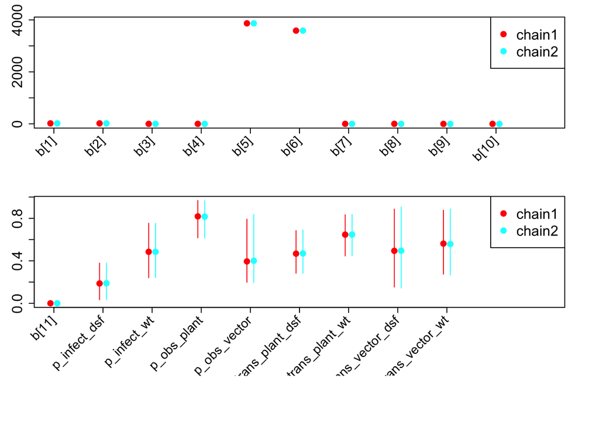

```r
chainsPlot(samples, nrows = 2, buffer.right = 1)
```

The effective sample size of the first chain is satisfactory, with a minimum of more than 1,000 effectively independent samples from all posterior dimensions, resulting from the 100,000 post burn-in samples.

```r
round(cbind(
    length = apply(samples[[1]], 2, length),
    ESS    = effectiveSize(samples[[1]])
))
```

```
                   length    ESS
b[1]                1e+05  18736
b[2]                1e+05  22825
b[3]                1e+05  18070
b[4]                1e+05  23375
b[5]                1e+05  98917
b[6]                1e+05 100000
b[7]                1e+05 100000
b[8]                1e+05 100000
b[9]                1e+05   3389
b[10]               1e+05   4125
b[11]               1e+05   5766
p_infect_dsf        1e+05  12218
p_infect_wt         1e+05  46633
p_obs_plant         1e+05   6337
p_obs_vector        1e+05   1049
p_trans_plant_dsf   1e+05   5533
p_trans_plant_wt    1e+05   6714
p_trans_vector_dsf  1e+05   1207
p_trans_vector_wt   1e+05   1873
```

### Posterior Mean, Median, and 95% Credible Intervals

```r
res <- round(cbind(
    `CI Lower` = apply(samples[[1]], 2, function(x) quantile(x, 0.025)),
    `Mean`         = apply(samples[[1]], 2, mean),
    `Median`       = apply(samples[[1]], 2, median),
    `CI Upper` = apply(samples[[1]], 2, function(x) quantile(x, 0.975))
), 5)

res
```

```
##                      CI Lower       Mean     Median   CI Upper
## b[1]                 17.59044   17.59054   17.59054   17.59063
## b[2]                 17.93634   17.93640   17.93640   17.93647
## b[3]                 -0.18262   -0.18253   -0.18253   -0.18244
## b[4]                 -0.27145   -0.27138   -0.27138   -0.27130
## b[5]               3786.75556 3867.82356 3867.76117 3949.72248
## b[6]               3535.18100 3587.43144 3587.35634 3640.04742
## b[7]                  0.00036    0.00037    0.00037    0.00037
## b[8]                  0.00024    0.00024    0.00024    0.00024
## b[9]                 -5.67220   -2.74282   -2.53613   -0.98923
## b[10]                -3.54095   -1.51418   -1.39876   -0.18771
## b[11]                 0.00005    0.00019    0.00019    0.00038
## p_infect_dsf          0.03360    0.18699    0.18148    0.37847
## p_infect_wt           0.24101    0.48481    0.48041    0.75359
## p_obs_plant           0.61640    0.81835    0.82768    0.96734
## p_obs_vector          0.19841    0.39460    0.36389    0.79186
## p_trans_plant_dsf     0.28316    0.46747    0.46171    0.68391
## p_trans_plant_wt      0.44567    0.64660    0.64899    0.83372
## p_trans_vector_dsf    0.15268    0.49404    0.48761    0.88711
## p_trans_vector_wt     0.27482    0.56191    0.56001    0.87632
```

### Interpretations (updated v5)

##### Bacteria concentration in source plants (constant terms)

$\beta_1$, the constant term in the log() predictor for source plant xf concentration in genotype DSF plants, is essentially 17.591. Thus, the baseline xf concentration (at distance=0) in genotype DFS plants is $e^{\beta_1} \approx$ 44,000,000.

$\beta_2$, the constant term in the log() predictor for source plant xf concentration in genotype WT plants, is essentially 17.936, slightly *higher* than the genotype DSF constant term. Thus, the baseline xf concentration (at distance=0) in genotype WT plants is $e^{\beta_2} \approx$ 62,000,000.

These values of $\beta_1$ and $\beta_2$ imply that for the *same distance*, genotype WT plants will have more xf bacteria than genotype DSF plants. Specifically, higher in the WT plants by a factor of $e^{\beta_2-\beta_1} = e^{0.346}=$ 1.413.

##### Bacteria concentration in source plants (distance effect)

$\beta_3$, the coefficient of distance in the log() predictor for source plant xf concentration in genotype DSF plants, is essentially -0.183. For every additional unit of distance, the source plant xf concentration in DSF plants will decrease by a factor of $e^{\beta_3}=$ 0.833.

$\beta_4$, the coefficient of distance in the log() predictor for vector xf concentration in genotype WT plants, is essentially -0.271. This is significantly lower than that of genotype DSF plants, implying that the xf concentration decreases more rapidly (as a function of distance) in genotype WT plants, as compared to genotype DSF plants. Specicially, for every additional unit of distance, the source plant xf concentration in WT plants will decrease by a factor of $e^{\beta_4}=$ 0.762.

##### Bacteria presence or absense in source plant: true negative detections (new v5)

We allow some probability that there is 0 bacteria present at the source plant test site, regardless of distance. This probability is allowed to vary between DSF and WT source plant genotypes.

For DSF source plants, the probability of bacteria being present is estimated as 0.467, with 95% credible interval (0.283, 0.684).

For WT source plants, the probability of bacteria being present is estimated as 0.647, with 95% credible interval (0.446, 0.834).

This means that on average, there was a 47% chance of any bacteria being present at the test site in DSF plants, and a 65% chance of any bacteria being present at the test site in WT plants.

##### Bacteria transmission from source plants to vectors (vector concentration effect)

For DSF source plants, $\beta_5$ and $\beta_7$ determine the linear relationship for how xf is transmitted to vectors, as $\lambda_{vector} = \beta_5 + \beta_7 \cdot \lambda_{source\ plant}$. We are interested in the $\beta_7$ coefficient, which is approximately equal to 0.00037. This means that for DSF source plants, the vector xf concentration increases at a rate of 0.00037 times the source plant xf concentration.

For WT source plants, $\beta_6$ and $\beta_8$ determine the linear relationship for how xf is transmitted to vectors, as $\lambda_{vector} = \beta_6 + \beta_8 \cdot \lambda_{source\ plant}$. We are interested in the $\beta_8$ coefficient, which is approximately equal to 0.00024. This means that for WT source plants, the vector xf concentration increases at a rate of 0.00024 times the source plant xf concentration. This is a much *lower transmission rate* from (source plants to vectors) for WT plants, as compared to DSF plants.

##### Bacteria transmission from source plants to vectors: true negative detections (new v5)

We allow some probability that 0 bacteria is transmitted to the vector, regardless of the bacteria concentration in the source plant. This probability is allowed to vary between DSF and WT source plant genotypes.

For DSF source plants, the probability of bacteria being transmitted to the vector is estimated as 0.494, with 95% credible interval (0.153, 0.887).

For WT source plants, the probability of bacteria being transmitted to the vector is estimated as 0.562, with 95% credible interval (0.275, 0.876).

The probability of transmission of bacteria to the vectors was extremely similar between DSF and WT plants. Given there was bacteria present at the source plant test site, then there is a 50% chance of transmission to the vector from DSF source plants, and a 56% chance of transmission from WT source plants. These estimates were not statistically significantly different.

##### Probability of test plant infection (genotype effect)

$\beta_{9}$ gives the baseline probability of infection (on the logit scale) for genotype DSF plants. The 95% CI for $\beta_{9}$ is (-5.67, -0.99). Taking the inverse-logit transformation $\left( \tfrac{1}{1+e^{-x}} \right)$, this gives a 95% CI for the baseline probability of infection for DSF source plants as (0, 0.27). This does not take xf concentration in the vector into account.

$\beta_{10}$ gives the baseline probability of infection (on the logit scale) for genotype WT plants. The 95% CI for $\beta_{10}$ is (-3.54, -0.19). Taking the inverse-logit transformation $\left( \tfrac{1}{1+e^{-x}} \right)$, this gives a 95% CI for the baseline probability of infection for WT source plants as (0.03, 0.45). This does not take xf concentration in the vector into account.

##### Probability of test plant infection (vector xf effect) (significant change v5)

$\beta_{11}$ is the coefficient for vector xf level in the logit() predictor for test plant infection. That is, this (on the logit scale) determines how vector xf concentration affects the probability of test plant infection.

This means that increased vector xf concentration does have a significant positive effect on the probability of test plant infection. It’s difficult to exactly quantify how much the probability of infection will increase as the vector xf concentration increases, since this coefficient is on the logit scale.

However, given that the observed (non-zero) vector xf concentrations are roughly between 1,000 and 60,000, this implies an increase (on the logit scale) of between (1000)(0.00019) = 0.19 and (60000)(0.00019) = 11.4. An increase of 0.19 (on the logit scale) implies a noteworthy, although not massive increase in the probability of infection; the increase of 11.4 (on the logit scale) is large enough to ensure a probability of infection essentially equal to 1.

##### Bacteria detection (source plants, vectors)

$p_{obs.\ source\ plant}$, the probability of xf detection in source plants, is bounded by the 95% CI (0.62, 0.97), with median 0.828. This means the test used has about an 83% chance of detecting any xf bacteria in source plants.

##### Predictive distributions for test plant infection

The predictive nodes give the best idea of the probability of infection, from either DSF or WT source plants, predicted at distance = 0. These estimates take all model parameters and biological processes into account.

- Probability of infection for genotype DSF (at distance = 0) is in the 95% CI: (0.03, 0.38), with median = 0.18.
- Probability of infection for genotype WT (at distance = 0) is in the 95% CI: (0.24, 0.75), with median = 0.48.

Next, we look at the probabilities of infection from *all test plants*, separated by genotype. These do not assume any particular distance (*e.g.*, distance = 0). Instead, these quite literally represent *all* distances in the input data set.

```r
dsf_ind <- intersect(which(constants$genotype_dsf == 1), constants$obs_ind_infected)
wt_ind  <- intersect(which(constants$genotype_wt  == 1), constants$obs_ind_infected)
pinfect_dsf_nodes <- paste0('p_infect[', dsf_ind, ']')
pinfect_wt_nodes  <- paste0('p_infect[', wt_ind,  ']')
pinfect_dsf <- as.numeric(samples2[, pinfect_dsf_nodes])
pinfect_wt  <- as.numeric(samples2[, pinfect_wt_nodes])
dsf_res <- c(quantile(pinfect_dsf,0.025), mean(pinfect_dsf), median(pinfect_dsf), quantile(pinfect_dsf,0.975))
wt_res <-  c(quantile(pinfect_wt, 0.025), mean(pinfect_wt ), median(pinfect_wt ), quantile(pinfect_wt, 0.975))
infection_results <- rbind(dsf_res, wt_res)
rownames(infection_results) <- c('p_infect_dsf', 'p_infect_wt')
colnames(infection_results) <- c("CI Lower", "Mean", "Median", "CI Upper")
round(infection_results, 2)
```

```
##              CI Lower Mean Median CI Upper
## p_infect_dsf     0.01 0.27   0.15     0.93
## p_infect_wt      0.06 0.46   0.36     0.98
```

We see that:

- Probabilities of infection for genotype DSF plants are in the 95% CI: (0.01, 0.93), with median = 0.15.
- Probabilities of infection for genotype WT plants are in the 95% CI: (0.06, 0.98), with median = 0.36.

This is not so surprising. It says that for each genotype, when we consider **all** plant, vector, and distance combinations, there’s huge variation (nearly spanning the interval [0, 1]) in the probability of test plant infection.

### Hierarchical Plots (updated v5)

Predicted probability of infection versus observed xf concentration in vectors (log base 10), separated by genotype. We include best-fit regression lines.

This plot has been updated since adding the new probabilistic models for zero xf transmissions, in the source plant and the vectors. The plot below shows how the probability of infection varies as a function of xf concentration in the vectors, for each plant genotype.

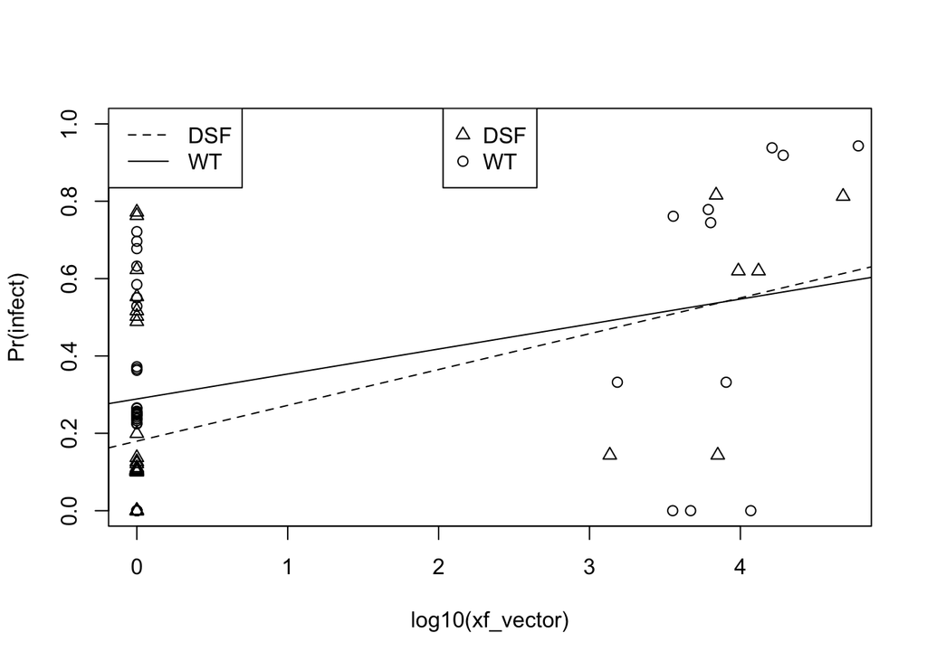

```r
## indices of DSF and WT cases for which xf_vector was observed
dsf_ind <- intersect(which(constants$genotype_dsf == 1), constants$obs_ind_vector)
wt_ind  <- intersect(which(constants$genotype_wt  == 1), constants$obs_ind_vector)
## get xf_vector values for each genotype, and take log base 10
xf_vector_dsf_log10 <- log10(data$xf_vector[dsf_ind])
xf_vector_wt_log10  <- log10(data$xf_vector[wt_ind])
## change -infinity to 0
xf_vector_dsf_log10[xf_vector_dsf_log10 < 0] <- 0
xf_vector_wt_log10 [xf_vector_wt_log10  < 0] <- 0
## get samples of p_infect for each genotype, and take the median
p_infect_dsf_nodes <- paste0('p_infect[', dsf_ind, ']')
p_infect_wt_nodes  <- paste0('p_infect[', wt_ind,  ']')
p_infect_dsf <- apply(samples2[, p_infect_dsf_nodes], 2, median, na.rm = TRUE)
p_infect_wt  <- apply(samples2[, p_infect_wt_nodes],  2, median, na.rm = TRUE)
## plot p_infect vs. xf_vector (for each genotype) + regression lines
plot(xf_vector_dsf_log10, p_infect_dsf, ylim = c(0, 1), xlab = 'log10(xf_vector)', ylab = 'Pr(infect)', pch = 2)
abline(lm(p_infect_dsf ~ xf_vector_dsf_log10), lty = 2)
points(xf_vector_wt_log10, p_infect_wt, pch = 1)
abline(lm(p_infect_wt ~ xf_vector_wt_log10), lty = 1)
legend('topleft', legend = c('DSF', 'WT'), lty = 2:1)
legend('top',      legend = c('DSF', 'WT'), pch = 2:1)
```

### Posterior Density Plots (updated v5)

##### Predictive distributions for test plant infection (significantly updated v5)

Below are the posterior predictive distributions for test plant infection, for genotype DSF and WT plants, predicted at distance = 0.

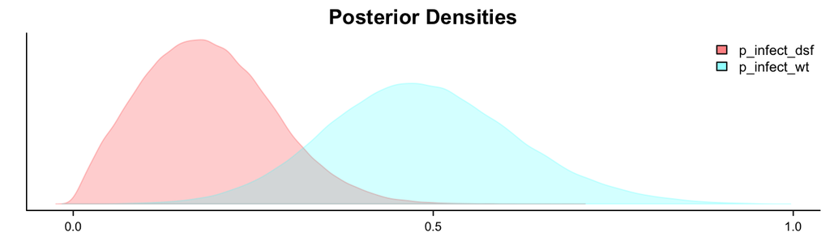

```r
samplesPlot(samples[[1]], c('p_infect_dsf','p_infect_wt'), width = 4, height = 2, traceplot = FALSE)
```

Below are the posterior predictive distributions for test plant infection, for genotype DSF and WT plants, for all distances.

These have changed greatly, since the addition of allowing zero-transmissions of xf bacteria from source plants, and also to vectors. These zero-transmission cases give rise to the bimodal distributions seen below, for probability of infection. The large modes near probability of infection = 0 represent those cases where there was zero transmission of bacteria either at the source plant, or to the vector, and hence the probability of infection is also zero.

The much larger mass near to probability of infection = 0 for the DSF genotype is explained by the results we’ve seen above. For DSF plants there was only a 47% chance of any bacteria being present at the source plant test site (versus 65% chance for WT plants; much more likely to have bacteria). And more minor, but still pushing the results in the same direction, the probability of bacteria transmission to the vectors was 50% for DSF source plants (versus a higher 56% for WT plants). Both of these results (from the new probabilistic transmission models) drive the results below, where there’s a large mode around probability of infection = 0 for DSF plants, and a similar but much smaller mode for WT source plants.

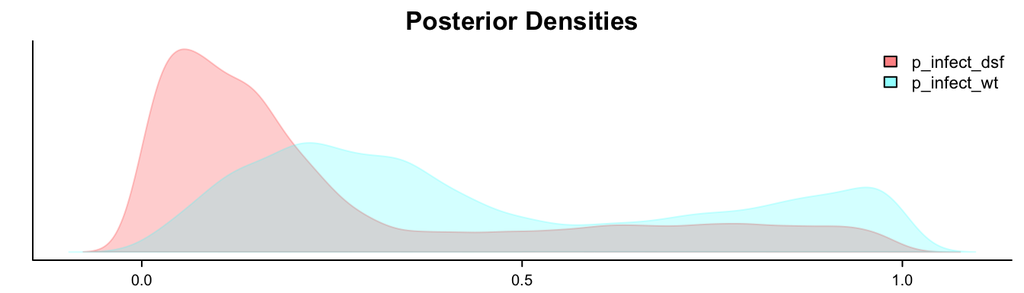

```r
set.seed(0)
pinfect_df <- data.frame(p_infect_dsf = sample(pinfect_dsf,length(pinfect_wt)),
                         p_infect_wt  = pinfect_wt)
samplesPlot(pinfect_df, c('p_infect_dsf','p_infect_wt'), width = 4, height = 2, traceplot = FALSE)
```

##### Posterior densities of transmission probabilities (new v5)

First, compare the posterior distributions of presense of xf bacteria at source plant test sites, for DSF and WT source plants.

We see a reasonable difference in these probabilities, namely that WT source plants are more likely to have bacteria present at the test site.

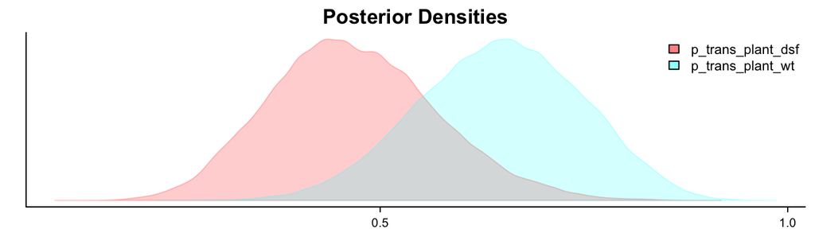

```r
samplesPlot(samples[[1]], c('p_trans_plant_dsf', 'p_trans_plant_wt'), width = 4, height = 2, traceplot = FALSE)
```

Next, compare the posterior distributions of transfer of xf bacteria from the source plant to the vectors, for DSF and WT source plants.

We see essentially no difference here between DSF at WT source plants. If bacteria are present at the test site, then vectors are equally likely to acquire the bacteria from either at DSF or a WT source plant.

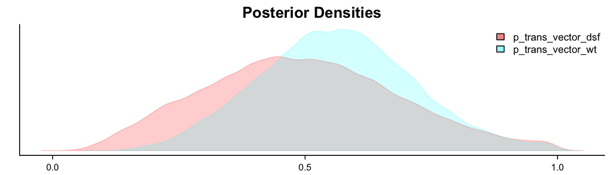

```r
samplesPlot(samples[[1]], c('p_trans_vector_dsf', 'p_trans_vector_wt'), width = 4, height = 2, traceplot = FALSE)
```

##### New Predictive plots

```r
library(dplyr)
```

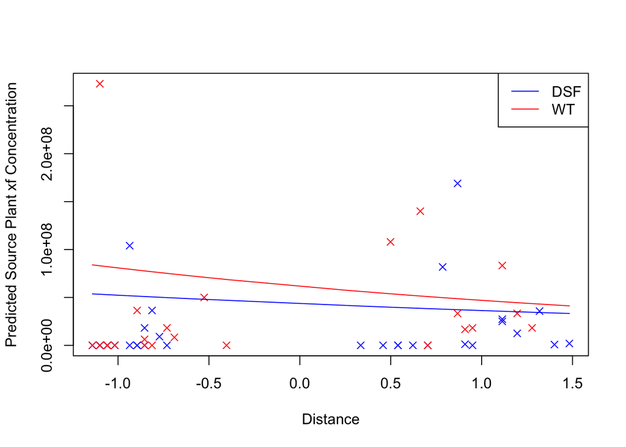

```r
dsf_ind <- constants$genotype_dsf == 1
wt_ind  <- constants$genotype_wt  == 1

pred_xf_source_plant <- samples2[,grep("^pred_xf_source_plant", colnames(samples2))]
pred_xf_vector       <- samples2[,grep("^pred_xf_vector",       colnames(samples2))]

pred_df <- data.frame(
    genotype = ifelse(constants$genotype_dsf, 'DSF', 'WT'),
    distance = constants$distance,
    xf_plant_med  = unname(apply(pred_xf_source_plant, 2, median)),
    xf_vector_med = unname(apply(pred_xf_vector,      2, median))
)

pred_df %>% arrange(distance) -> pred_df
pred_df %>% filter(genotype == 'DSF') -> pred_df_dsf
pred_df %>% filter(genotype == 'WT')  -> pred_df_wt

plot(-10, -10,
     xlim = range(pred_df$distance),
     ylim = range(data$xf_source_plant, na.rm = TRUE),
     xlab = 'Distance', ylab = 'Predicted Source Plant xf Concentration')
points(constants$distance[dsf_ind], y = data$xf_source_plant[dsf_ind], col = 'blue', pch = 4)
points(constants$distance[wt_ind],  y = data$xf_source_plant[wt_ind],  col = 'red',  pch = 4)
lines(pred_df_dsf$distance, pred_df_dsf$xf_plant_med, col = 'blue')
lines(pred_df_wt$distance,  pred_df_wt$xf_plant_med,  col = 'red')
legend(legend = c('DSF', 'WT'), 'topright', col = c('blue', 'red'), lty = 1)
```

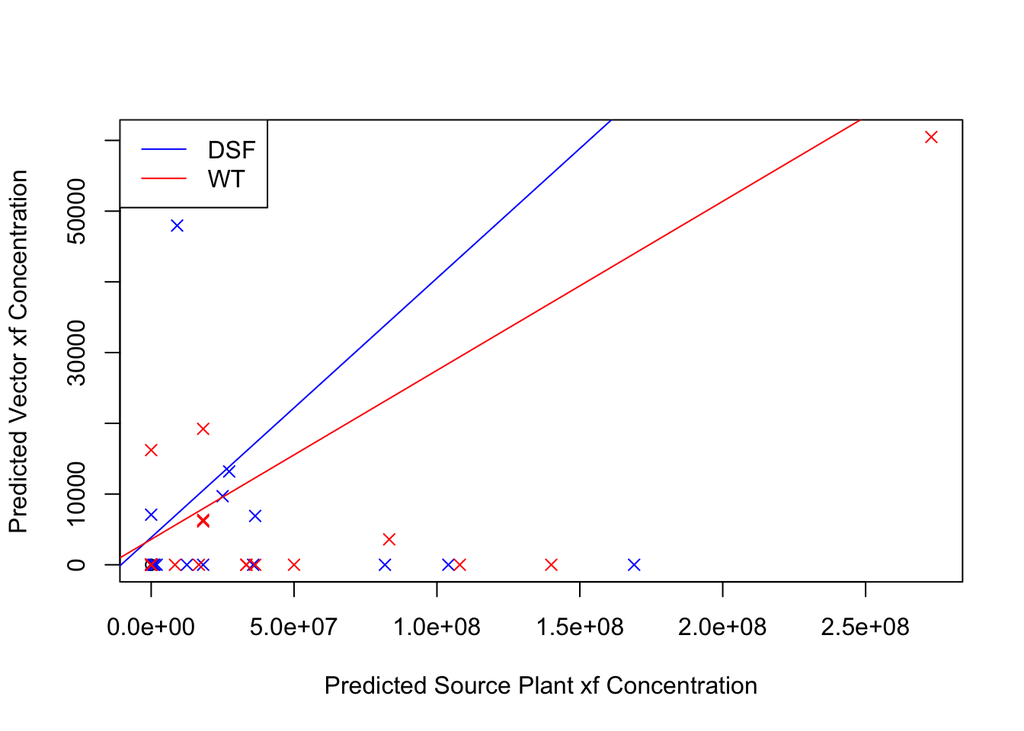

```r
plot(-10, -10,
     xlim = range(data$xf_source_plant, na.rm = TRUE),
     ylim = range(data$xf_vector, na.rm = TRUE),
     xlab = 'Predicted Source Plant xf Concentration', ylab = 'Predicted Vector xf Concentration')
points(data$xf_source_plant[dsf_ind], y = data$xf_vector[dsf_ind], col = 'blue', pch = 4)
points(data$xf_source_plant[wt_ind],  y = data$xf_vector[wt_ind],  col = 'red',  pch = 4)
abline(lm(xf_vector_med ~ xf_plant_med, data = pred_df_dsf), col = 'blue')
abline(lm(xf_vector_med ~ xf_plant_med, data = pred_df_wt),  col = 'red')
legend(legend = c('DSF', 'WT'), 'topleft', col = c('blue', 'red'), lty = 1)
```

##### Posterior densities of all model parameters

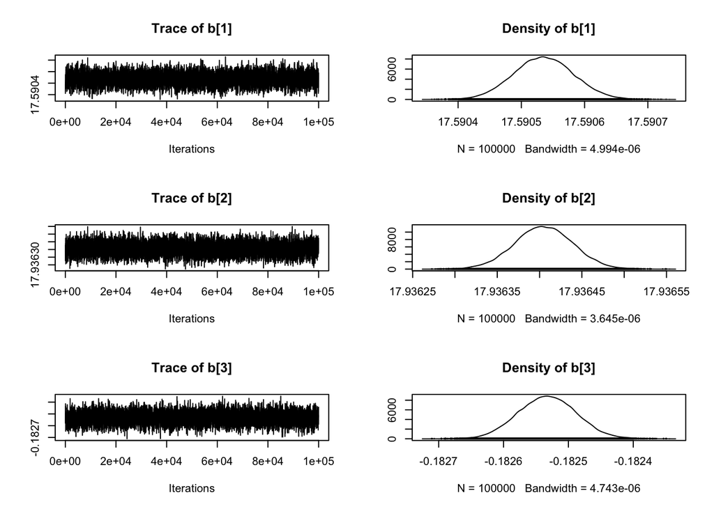

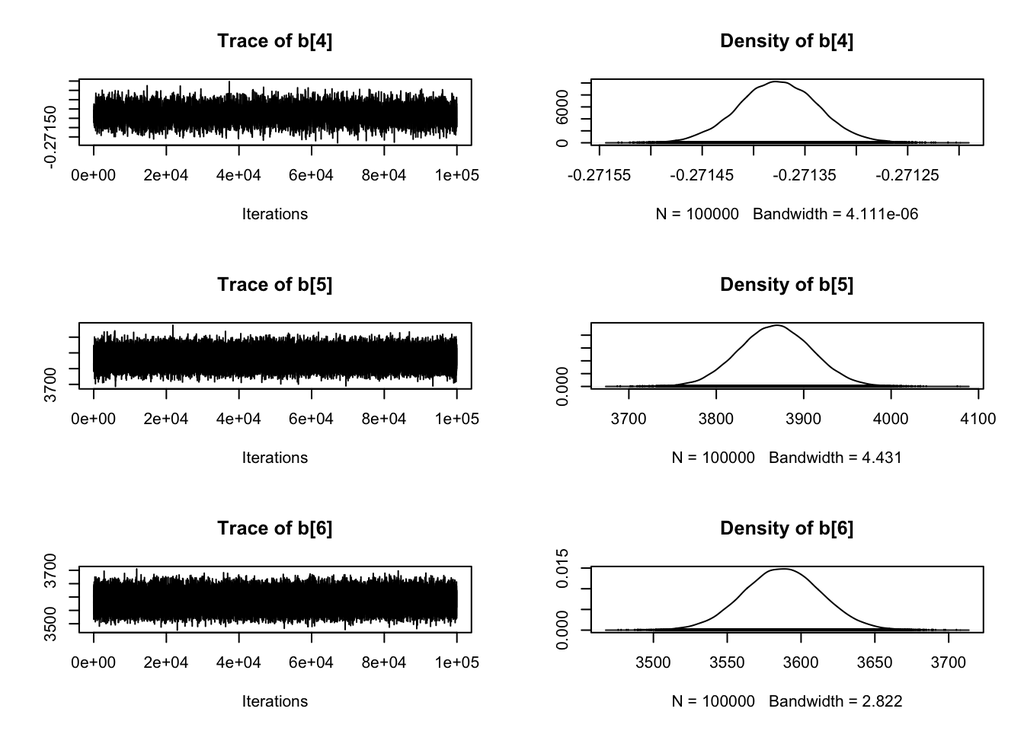

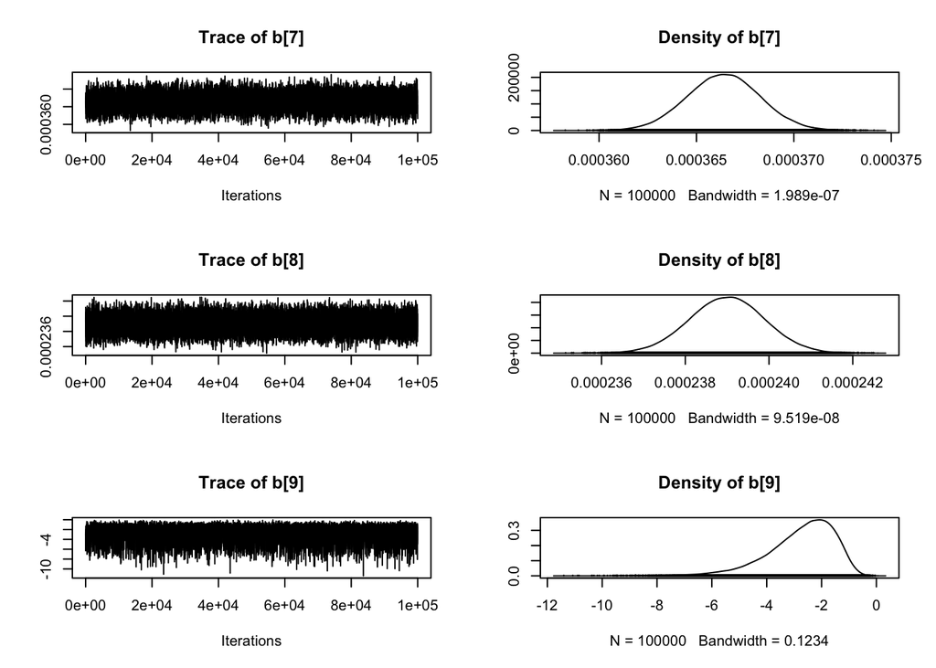

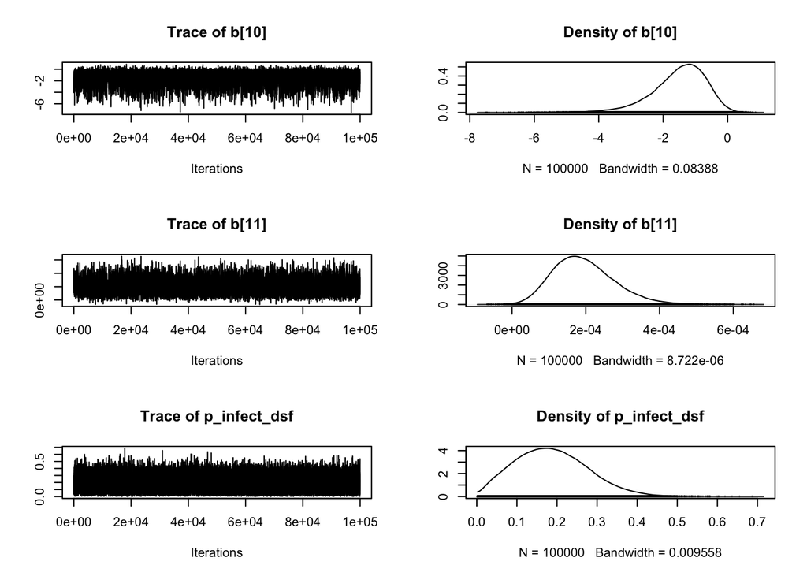

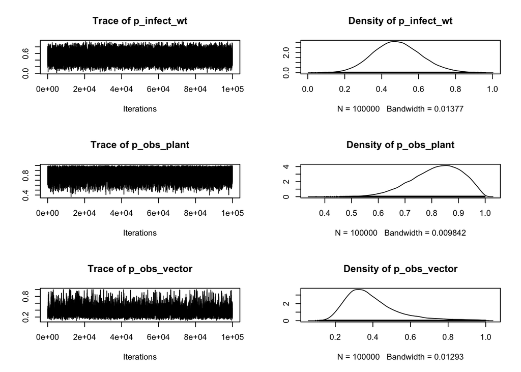

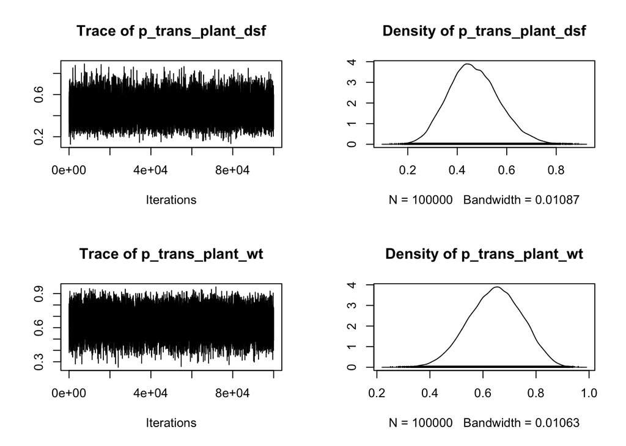

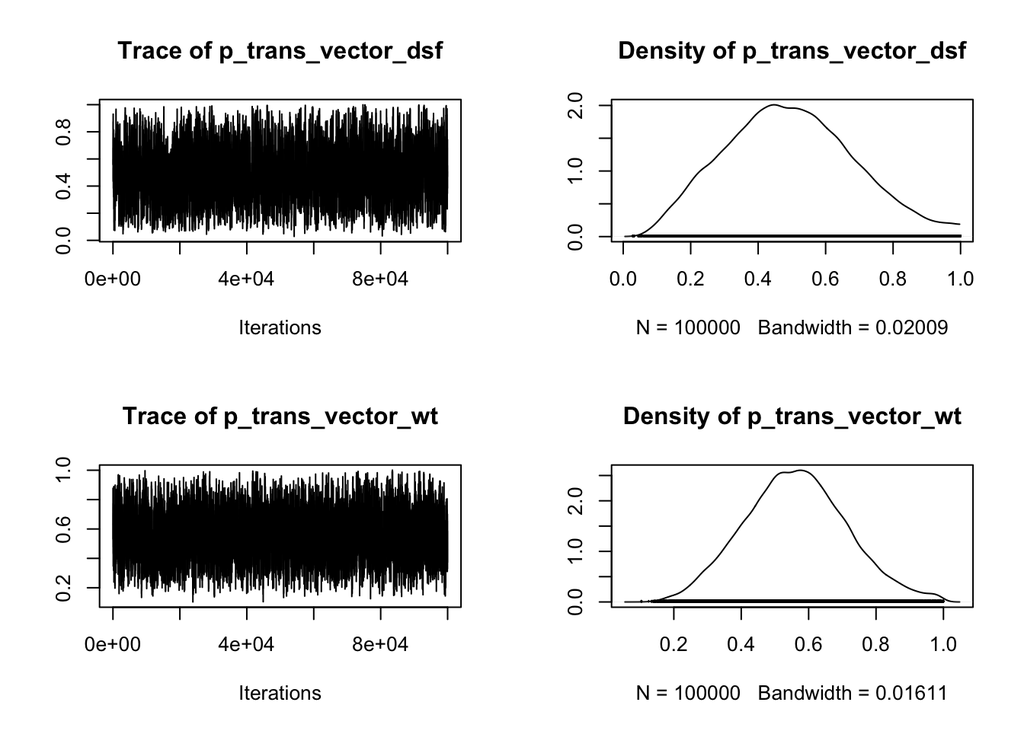

```r
plot(coda::as.mcmc(samples[[1]]), ask = FALSE)
```

### References

Tibbits, Matthew M, Chris Groendyke, Murali Haran, and John C Liechty. 2014. “Automated Factor Slice Sampling.” *Journal of Computational and Graphical Statistics* 23 (2). Taylor & Francis: 543–63.